# Modelos ARMA - R

Andreza Palma

Lembre-se de instalar os pacotes que você ainda não instalou antes de carregar.

```r
library(BatchGetSymbols) ### pegar dados yahoo finance (preços diárias ativos negociados em bolsa)
library(tidyverse)
library(ggthemes)
library(FinTS)
library(WriteXLS)
library(xtable)
library(tbl2xts)
library(forecast)
library(tseries)
library(timeSeries)
```

```r
#ticker IBOVESPA
tickers<-c("^BVSP")

ibov<- BatchGetSymbols(tickers,
                                 first.date = '2021-10-27',
                                 last.date = Sys.time(),
                                 type.return = "log",
                                 freq.data = "daily")
```

```
##
## Running BatchGetSymbols for:
##    tickers =^BVSP
## ^GSPC | yahoo (1|1) | Not Cached | Saving cache
## ^BVSP | yahoo (1|1) | Not Cached | Saving cache - Got 96% of valid prices | Nice!
```

```r
ibov <- ibov[[2]]
```

Vamos selecionar os retornos diários da série do IBOVESPA e separar as datas da série de retornos, além de declarar a variável como série temporal.

```r
daily_returns <- ibov %>%
  select(ref.date,ret.closing.prices)

date <- daily_returns %>%
  select(ref.date) %>%
  rename(date = ref.date) %>%
  slice(-1)

daily_returns <- daily_returns %>%
  select(ret.closing.prices) %>%
  slice(-1)

## declarando como série temporal através do comando as.ts
daily_returns=as.ts(daily_returns)
head(daily_returns,5)
```

```
## Time Series:
## Start = 1
## End = 5
## Frequency = 1
##      ret.closing.prices
## [1,]      -0.0062055766
## [2,]      -0.0210709210
## [3,]       0.0196129739
## [4,]       0.0006250947
## [5,]      -0.0210983337
```

```r
auto.arima(daily_returns)
```

```
## Series: daily_returns
## ARIMA(2,0,2) with zero mean
##
## Coefficients:
##           ar1      ar2     ma1     ma2
##       -0.9053  -0.7850  0.9593  0.7668
## s.e.   0.1717   0.1344  0.1779  0.1477
##
## sigma^2 = 0.0001319:  log likelihood = 2004.39
## AIC=-3998.79   AICc=-3998.69   BIC=-3976.35
```

**IDENTIFICAÇÃO DO MODELO**

FAC e FACP

Para ter uma ideia do modelo a ser estimado, usamos as FAC e FACP, como visto em aula. Podemos estipular o número máximo de defasagens a ser incluído através de lag.max.

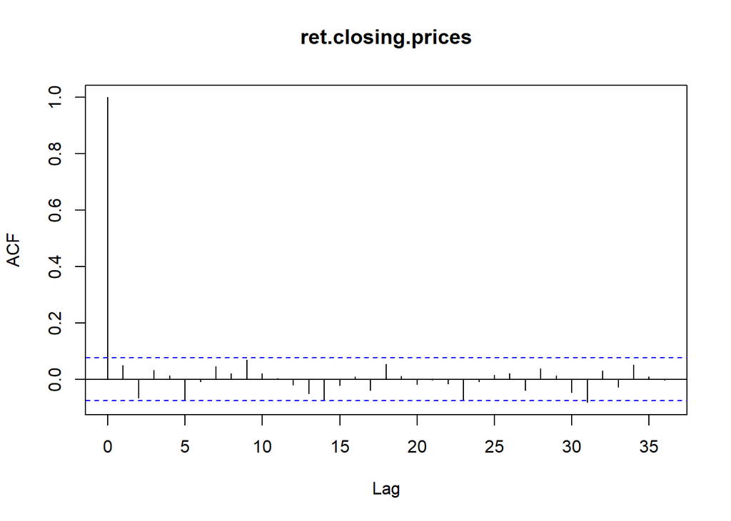

```r
acf(daily_returns, lag.max=36)
```

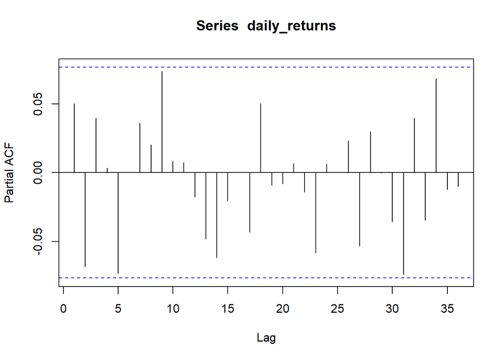

```r
pacf(daily_returns, lag.max=36)
```

É possível usar também tsdisplay:

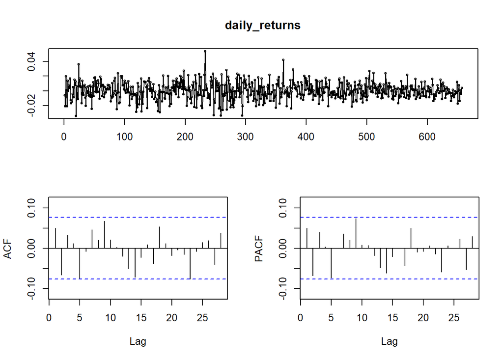

```r
tsdisplay(daily_returns)
```

**Estimação do modelo ARMA**

```r
x=arima(daily_returns,order=c(2,0,2))
```

**Diagnóstico do modelo** Após estimar o modelo, é preciso verificar se o mesmo é adequado através da análise dos resíduos, que devem ter o comportamento de ruído branco. Podemos ver isso através da estatística Q (teste de Box-Pierce e Ljung-Box), das FAC e FACP e da análise visual do gráfico dos resíduos.

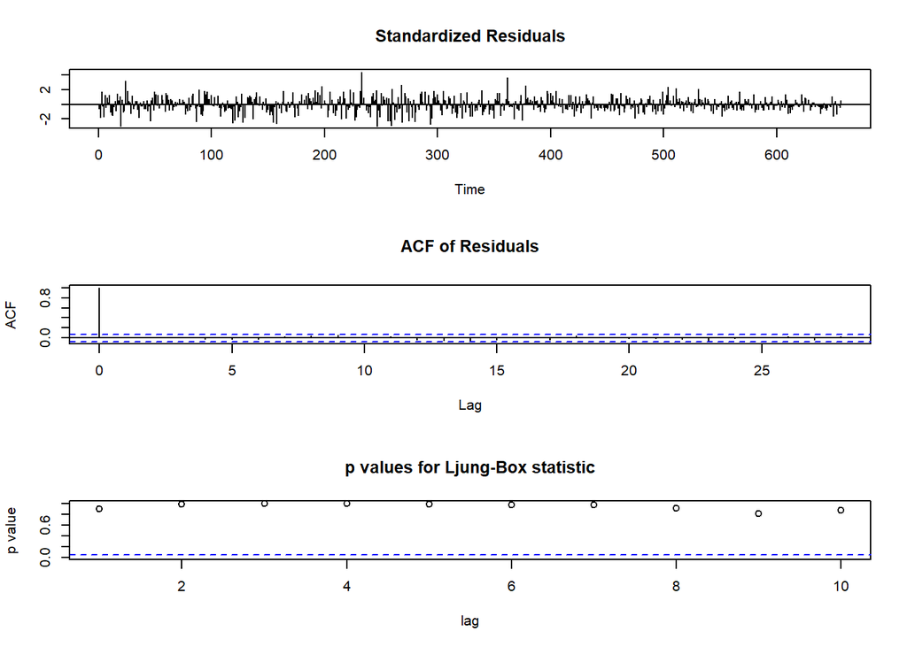

```r
tsdiag(x)
```

```r
Box.test(x$residuals,lag=1)
```

```
##
##  Box-Pierce test
##
## data:  x$residuals
## X-squared = 0.01652, df = 1, p-value = 0.8977
```

```r
Box.test(residuals(x),  type="Ljung")
```

```
##
##  Box-Ljung test
##
## data:  residuals(x)
## X-squared = 0.016596, df = 1, p-value = 0.8975
```

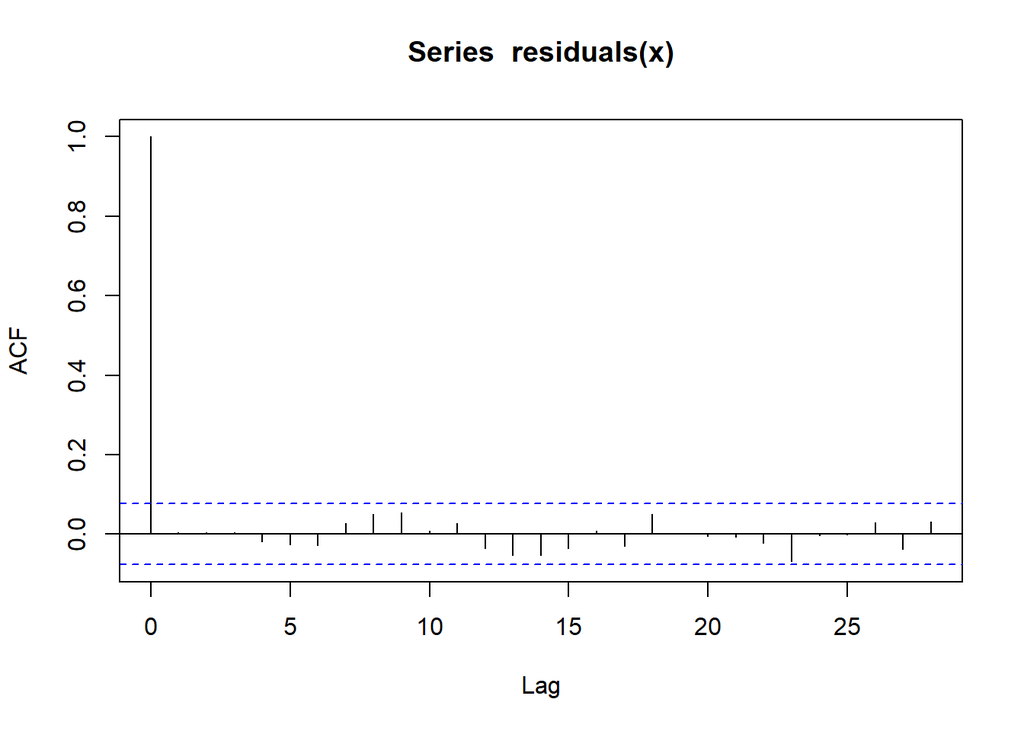

```r
acf(residuals(x))
```

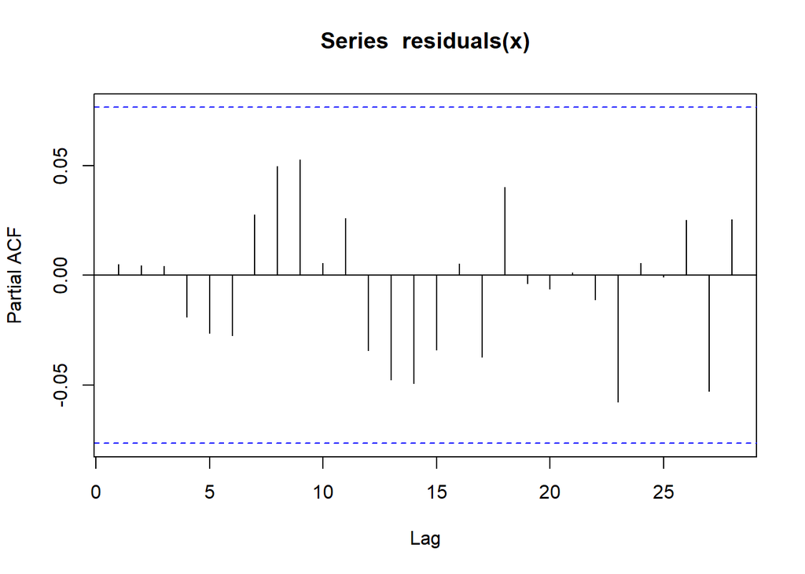

```r
pacf(residuals(x))
```

Gráfico dos resíduos

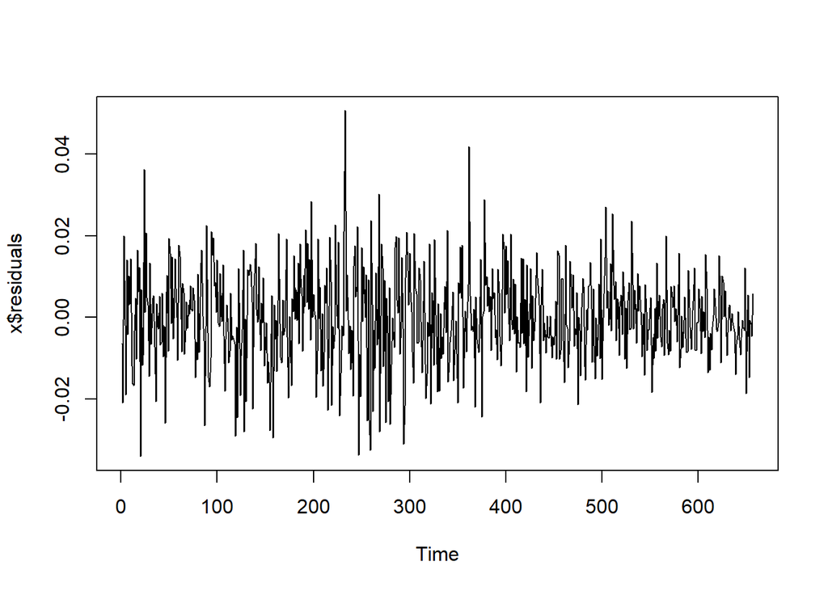

```r
plot.ts(x$residuals)
```

**Previsão**

```r
forecast<-predict(x,n.ahead=4, se.fit=T)
#(4 passos a frente)
#Com desvio-padrão
#predict(x, n.ahead = 15, se.fit=T)
forecast
```

```
## $pred
## Time Series:
## Start = 658
## End = 661
## Frequency = 1
## [1]  0.0023112881 -0.0003490950 -0.0009856552  0.0016696359
##
## $se
## Time Series:
## Start = 658
## End = 661
## Frequency = 1
## [1] 0.01144803 0.01146465 0.01149069 0.01149267
```

Formas alternativas

```r
forecast(x, 5)
```

```
##     Point Forecast       Lo 80      Hi 80       Lo 95      Hi 95
## 658   0.0023112881 -0.01235995 0.01698253 -0.02012644 0.02474901
## 659  -0.0003490950 -0.01504163 0.01434345 -0.02281940 0.02212121
## 660  -0.0009856552 -0.01571156 0.01374025 -0.02350699 0.02153568
## 661   0.0016696359 -0.01305882 0.01639809 -0.02085559 0.02419486
## 662  -0.0002243733 -0.01496231 0.01451356 -0.02276410 0.02231536
```

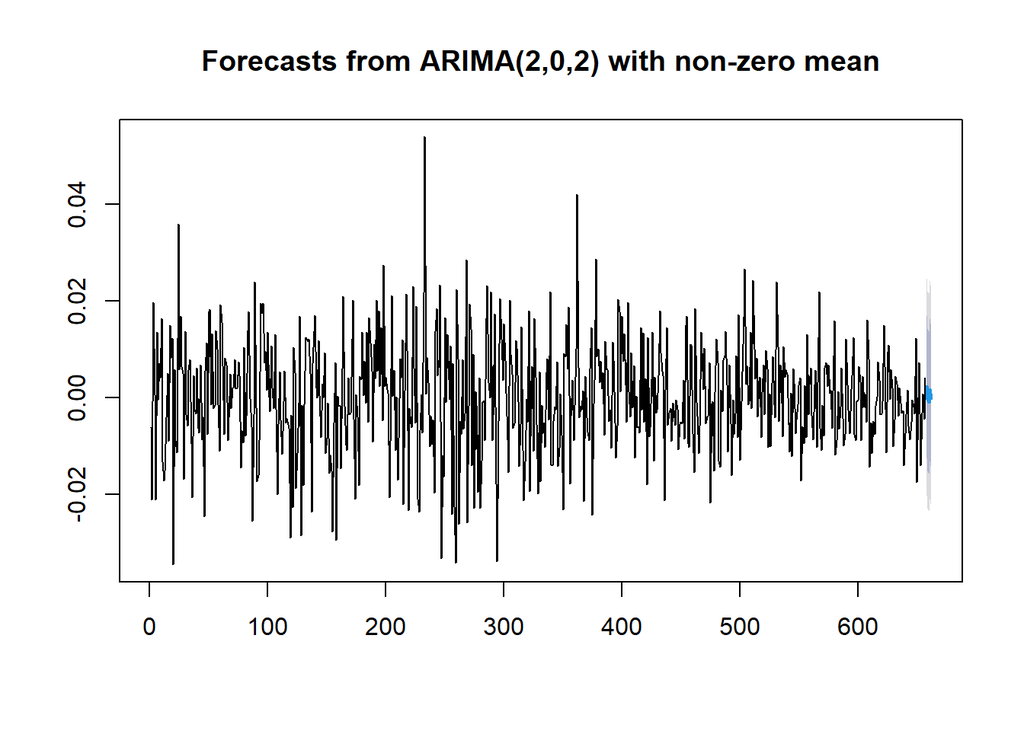

```r
plot(forecast(x, 5))
```

Valores ajustados x observados

Para ter uma idéia do ajuste do modelo, plotamos a série observada com a série estimada:

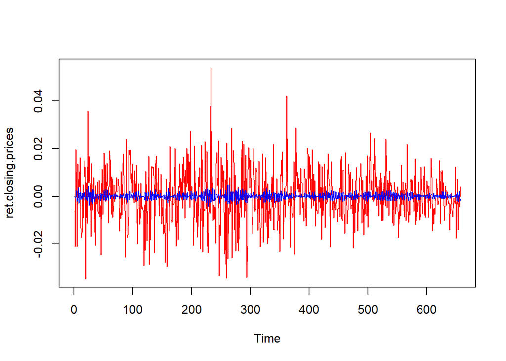

```r
plot(daily_returns, col="red")
lines(fitted(x),col="blue")
```

**FUNÇÃO AUTOARIMA**

Escolhe a “melhor” configuração do modelo

```r
auto.arima(daily_returns)
```

```
## Series: daily_returns
## ARIMA(2,0,2) with zero mean
##
## Coefficients:
##           ar1      ar2     ma1     ma2
##       -0.9053  -0.7850  0.9593  0.7668
## s.e.   0.1717   0.1344  0.1779  0.1477
##
## sigma^2 = 0.0001319:  log likelihood = 2004.39
## AIC=-3998.79   AICc=-3998.69   BIC=-3976.35
```